# Lesson 2 - R the Calculator

Stats 20 – Section 1 – Vivian Lew

Due July 1, 2020 by 11:59PM PDT

## 1. R is a kind of calculator

### The operators and their order (from help(Syntax))

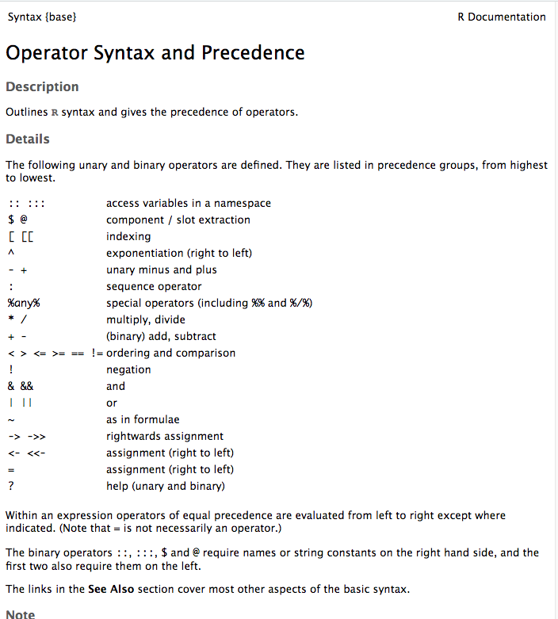

1. Result of help(Syntax)

### A couple of miscellaneous mathematical functions (from help(MathFun))

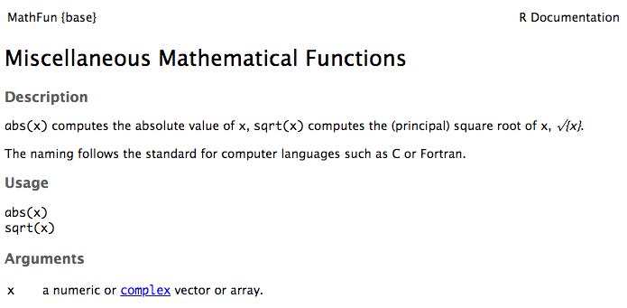

2. Result of help(MathFun)

### (not for credit) test yourself and see if you can find the help page for:

- Logarithms and Exponentials
- Trigonometric Functions

they should be found in base R.

## 2. Reserved Words

Listed among the most difficult things in Computer Science: 1. Naming Things.

There are some rules about naming objects in R, but they can always be broken. So really, R has no naming rules (!) For example, object names shouldn’t have spaces:

```r
no spaces <- 1:10
```

```
## Error: <text>:1:4: unexpected symbol
## 1: no spaces
##        ^
```

but when used with a backtick:

```r
`no spaces` <- 1:10
`no spaces`
```

```
##  [1]  1  2  3  4  5  6  7  8  9 10
```

we can have spaces in our object names (this is frowned upon, but it does work). This backtick feature can lead to great confusion…

```r
`2` <- 1
2 + 1
```

```
## [1] 3
```

```r
`2` + 1
```

```
## [1] 2
```

cheap advice, just keep your naming simple. Here are some reserved words (again, the backtick can change all of this) that you really should avoid modifying:

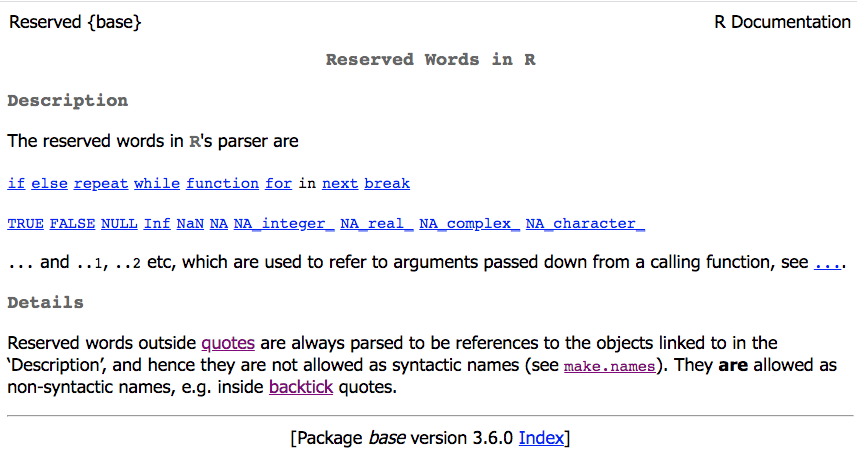

3. Reserved Words in R

## 3. Help in R

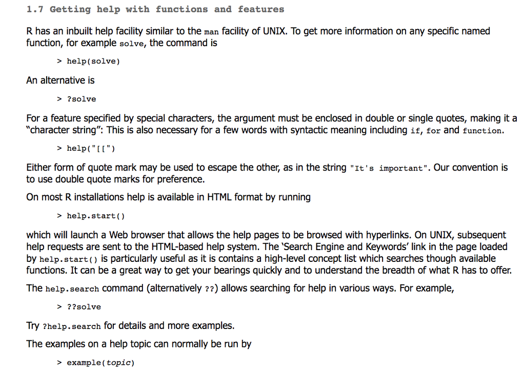

4. How to get some help

## 4. Answer these Questions Using R

A. 9 ÷ 3 + 7 x 5 x 6 + 16

B. 24 ÷ 3 x 4 - 3 + 7

C. 10 - 4 + 7 + 3 x (24 ÷ 4)

D. √16 ÷ 2^3

E. First find log<sub>e</sub> 0.3 and save it to an object. Then, use the object and compute its inverse using the exponential function.

F. Use R to create a vector with all integers from 1 to 100 that are not divisible by 2, 3, or 5 (this can be accomplished with one line of R, but at this point, just try to get the right numbers and work towards one line)

G. Create an object in R with a name that either has spaces or starts with a number or has punctuation other than a period in it.  
H. Please demonstrate that you know how to use the following six order and comparison operators by writing a little code (example given in the lesson submission template) that results in the R response TRUE :

< > <= >= == !=

I. Try the programming the following in R 3 times using 3 different finite values:

```
Choose any finite value
Double it.
Add 2.
Divide by 2.
Add 12.
Subtract your original number.
```

Your code and results should be clear in your rendered html file.

J. Suppose I were to rewrite the operations of the previous question as a function named “trick”:

```r
trick <- function(x){
  y <- x*2
  y <- y+2
  y <- y/2
  y <- y + 12
  y - x
}
```

it works, we can test it:

```r
trick(-7)
```

```
## [1] 13
```

```r
trick(18)
```

```
## [1] 13
```

```r
trick(5000000)
```

```
## [1] 13
```

But this is awkward and inefficient, please rewrite the function trick and name it trick2 and instead of using 5 lines of code:

```
  y <- x*2
  y <- y+2
  y <- y/2
  y <- y + 12
  y - x
```

please make it one line. FYI functions in R return the last value we don’t need a return.

and please use these three values as a test:

```r
trick2(-7)
```

```
## [1] 13
```

```r
trick2(18)
```

```
## [1] 13
```

```r
trick2(5000000)
```

```
## [1] 13
```

## 5. What to Turn in For Credit

Name your file Lastname_Firstname_Lesson02.Rmd

You can find a template on CCLE just after the lesson 2 link.

This is an R Markdown file and for full credit it should run without error when I source your submission. Turn in both an .Rmd file as requested in #5 and a rendered .html file with your ansewrs for #4.